# On Recursion

## Agenda

1. Recursion
   - stopping recursion: simplification & base cases
2. Recursive "shapes":
   - Linear (single) recursion:
     - Factorial
     - Addition
     - Binary search
   - Tree (multiple) recursion: *divide and conquer*
     - Fibonacci numbers
     - Tower of Hanoi
     - Merge sort
     - Making change
3. The Call Stack and Stack Frames
   - simulating recursion
   - debugging with `pdb` and `%debug`

## 1. Recursion

Recursive functions, directly or indirectly, call themselves.

Recursive solutions are applicable when a problem can be broken down into more easily solved sub-problems that resemble the original, and whose solutions can then be combined.

E.g., computing the combined price of a bunch of nested shopping bags of items:

```python
class Bag:
    def __init__(self, price, *contents):
        self.price = price
        self.contents = contents
```

```python
bag1 = Bag(10)
```

```python
bag2 = Bag(5, Bag(3))
```

```python
bag3 = Bag(5, Bag(4, Bag(3)), Bag(2))
```

```python
bag4 = Bag(0, Bag(5), Bag(10), Bag(3, Bag(2), Bag(100)), Bag(9, Bag(2, Bag(25))))
```

```python
def price(bag):
    p = bag.price
    for b in bag.contents:
        p += price(b)
    return p
```

```python
price(bag4)
```

```
156
```

### Stopping recursion: simplification & base case(s)

```python
import sys
sys.setrecursionlimit(100)
```

```python
def silly_rec(n):
    if n == 0: # base case
        return
    n = n - 1 # simplify
    silly_rec(n)
```

```python
silly_rec(10)
```

To help visualize the recursive process, we can simply substitute the value of the parameter in each recursive call.

E.g., for `silly_rec(5)`:

silly_rec(5) -> silly_rec(4) -> silly_rec(3) -> silly_rec(2) -> silly_rec(1) -> silly_rec(0) # encounter base case

## 2. Recursive "shapes"

### Linear recursion

#### Example: Factorial

$n! = \begin{cases} 1 & \text{if}\ n=0 \\ n \cdot (n-1)! & \text{if}\ n>0 \end{cases}$

i.e., $n! = n \cdot (n-1) \cdot (n-2) \cdots 3 \cdot 2 \cdot 1$

```python
def rec_factorial(n):
    print('n = ', n)
    if n == 0:
        return 1
    else:
        return n * rec_factorial(n-1)

rec_factorial(10)
```

```
n =  10
n =  9
n =  8
n =  7
n =  6
n =  5
n =  4
n =  3
n =  2
n =  1
n =  0
```

```
3628800
```

#### Example: Addition of two positive numbers $m$, $n$

$m + n = \begin{cases} m & \text{if}\ n=0 \\ (m + 1) + (n - 1) & \text{if}\ n > 0 \end{cases}$

```python
def add(m, n):
    print('m, n = ', (m, n))
    if n == 0:
        return m
    else:
        return add(m+1, n-1)
```

```python
add(5, 0)
```

```
m, n =  (5, 0)
```

```
5
```

```python
add(5, 1)
```

```
m, n =  (5, 1)
m, n =  (6, 0)
```

```
6
```

```python
add(5, 5)
```

```
m, n =  (5, 5)
m, n =  (6, 4)
m, n =  (7, 3)
m, n =  (8, 2)
m, n =  (9, 1)
m, n =  (10, 0)
```

```
10
```

#### Example: Binary search

```python
def bin_search(x, lst):
    if len(lst) == 0:
        return False
    else:
        print('lo, hi = ', (lst[0], lst[-1]))
        mid = len(lst) // 2
        if x == lst[mid]:
            return True
        elif x < lst[mid]:
            return bin_search(x, lst[:mid])
        else:
            return bin_search(x, lst[mid+1:])
```

```python
bin_search(20, list(range(100)))
```

```
lo, hi =  (0, 99)
lo, hi =  (0, 49)
lo, hi =  (0, 24)
lo, hi =  (13, 24)
lo, hi =  (20, 24)
lo, hi =  (20, 21)
lo, hi =  (20, 20)
```

```
True
```

```python
bin_search(-1, list(range(100)))
```

```
lo, hi =  (0, 99)
lo, hi =  (0, 49)
lo, hi =  (0, 24)
lo, hi =  (0, 11)
lo, hi =  (0, 5)
lo, hi =  (0, 2)
lo, hi =  (0, 0)
```

```
False
```

```python
bin_search(50.5, list(range(100)))
```

```
lo, hi =  (0, 99)
lo, hi =  (51, 99)
lo, hi =  (51, 74)
lo, hi =  (51, 62)
lo, hi =  (51, 56)
lo, hi =  (51, 53)
lo, hi =  (51, 51)
```

```
False
```

### Tree recursion

#### Example: Fibonacci numbers

$fib(n) = \begin{cases} 0 & \text{if}\ n=0 \\ 1 & \text{if}\ n=1 \\ fib(n-1) + fib(n-2) & \text{otherwise} \end{cases}$

i.e., 0, 1, 1, 2, 3, 5, 8, 13, 21, ...

```python
def rec_fib(n):
    print('n = ', n)
    if n == 0 or n == 1:
        return n
    else:
        return rec_fib(n-1) + rec_fib(n-2)

rec_fib(5)
```

```
n =  5
n =  4
n =  3
n =  2
n =  1
n =  0
n =  1
n =  2
n =  1
n =  0
n =  3
n =  2
n =  1
n =  0
n =  1
```

```
5
```

#### Example: Tower of Hanoi

Setup: three rods, with one or more discs of different sizes all stacked on one rod, smallest (top) to largest (bottom). E.g.,

```
     ||          ||          ||
     ==          ||          ||
    ====         ||          ||
   ======        ||          ||
------------------------------------
```

Goal: move all the discs, one by one, to another rod, with the rules being that (1) only smaller discs can be stacked on larger ones and (2) only the top disc in a stack can be moved to another rod.

For three discs, as shown above, we would carry out the following sequence to move the stack to the rightmost rod. The rods are abbreviated L (left), M (middle), R (right):

1. Move the small disc (0) from L to R
2. Move the medium disc (1) from L to M
3. Move 0 from R to M (R is empty)
4. Move the large disc (2) from L to R
5. Move 0 from M to L
6. Move 1 from M to R
7. Move 0 from L to R (done)

Can you come up with the sequence needed to move a stack of 4 discs from one rod to another? 5 discs? An arbitrary number of discs?

```python
height = 5
towers = [[] for _ in range(3)]
towers[0] = list(range(height, 0, -1))

def move(frm, to):
    towers[to].append(towers[frm].pop(-1))
    display()

def hanoi(frm, to, using, levels):
    if levels == 1:
        move(frm, to)
    else:
        hanoi(frm, using, to, levels-1)
        move(frm, to)
        hanoi(using, to, frm, levels-1)
```

```python
towers
```

```
[[5, 4, 3, 2, 1], [], []]
```

```python
from time import sleep
from IPython.display import clear_output

def display():
    clear_output(True)
    print('{:^12}'.format('||') * 3)
    for level in range(height, 0, -1):
        for t in towers:
            try:
                print('{:^12}'.format('==' * t[level-1]), end='')
            except IndexError:
                print('{:^12}'.format('||'), end='')
        print()
    print('-' * 36)
    sleep(1)
```

```python
hanoi(0, 2, 1, 5)
```

```
     ||          ||          ||
     ||          ||          ==
     ||          ||         ====
     ||          ||        ======
     ||          ||       ========
     ||          ||      ==========
------------------------------------
```

#### Example: Mergesort

```python
def merge(l1, l2):
    merged = []
    i1 = i2 = 0
    while i1 < len(l1) or i2 < len(l2):
        if i2 == len(l2) or (i1 < len(l1)
                             and l1[i1] < l2[i2]):
            merged.append(l1[i1])
            i1 += 1
        else:
            merged.append(l2[i2])
            i2 += 1
    return merged
```

```python
l1 = [1, 5, 9]
l2 = [2, 6, 8, 11]
merge(l1, l2)
```

```
[1, 2, 5, 6, 8, 9, 11]
```

```python
def mergesort(lst, lo, hi):
    if lo > hi:
        return []
    elif lo == hi:
        return lst[lo:lo+1]
    else:
        mid = (lo + hi) // 2
        return merge(mergesort(lst, lo, mid),
                     mergesort(lst, mid+1, hi))
```

```python
import random
lst = list(range(10))
random.shuffle(lst)
```

```python
mergesort(lst, 0, len(lst))
```

```
[0, 1, 2, 3, 4, 5, 6, 7, 8, 9]
```

```python
def insertion_sort(lst):
    for i in range(1, len(lst)):
        for j in range(i, 0, -1):
            if lst[j-1] > lst[j]:
                lst[j-1], lst[j] = lst[j], lst[j-1] # swap
            else:
                break
```

```python
class Heap:
    def __init__(self):
        self.data = []

    @staticmethod
    def _parent(idx):
        return (idx-1)//2

    @staticmethod
    def _left(idx):
        return idx*2+1

    @staticmethod
    def _right(idx):
        return idx*2+2

    def _heapify(self, idx=0):
        while True:
            l = Heap._left(idx)
            r = Heap._right(idx)
            maxidx = idx
            if l < len(self) and self.data[l] > self.data[idx]:
                maxidx = l
            if r < len(self) and self.data[r] > self.data[maxidx]:
                maxidx = r
            if maxidx != idx:
                self.data[idx], self.data[maxidx] = self.data[maxidx], self.data[idx]
                idx = maxidx
            else:
                break

    def add(self, x):
        self.data.append(x)
        i = len(self.data) - 1
        p = Heap._parent(i)
        while i > 0 and self.data[p] < self.data[i]:
            self.data[p], self.data[i] = self.data[i], self.data[p]
            i = p
            p = Heap._parent(i)

    def max(self):
        return self.data[0]

    def pop_max(self):
        ret = self.data[0]
        self.data[0] = self.data[len(self.data)-1]
        del self.data[len(self.data)-1]
        self._heapify()
        return ret

    def __bool__(self):
        return len(self.data) > 0

    def __len__(self):
        return len(self.data)


def heapsort(iterable):
    heap = Heap()
    for x in iterable:
        heap.add(x)
    sorted_lst = []
    while heap:
        sorted_lst.append(heap.pop_max())
    sorted_lst.reverse()
    return sorted_lst
```

```python
import timeit
import random
insertionsort_times = []
heapsort_times = []
mergesort_times = []
for size in range(100, 3000, 100):
    insertionsort_times.append(timeit.timeit(stmt='insertion_sort(lst)',
                               setup='import random ; from __main__ import insertion_sort ; '
                                         'lst = [random.random() for _ in range({})]'.format(size),
                               number=1))
    heapsort_times.append(timeit.timeit(stmt='heapsort(lst)',
                               setup='import random ; from __main__ import heapsort ; '
                                         'lst = [random.random() for _ in range({})]'.format(size),
                               number=1))
    mergesort_times.append(timeit.timeit(stmt='mergesort(lst, 0, {}-1)'.format(size),
                               setup='import random ; from __main__ import mergesort ; '
                                         'lst = [random.random() for _ in range({})]'.format(size),
                               number=1))
```

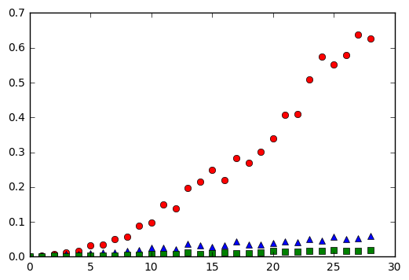

```python
%matplotlib inline
import matplotlib.pyplot as plt
plt.plot(insertionsort_times, 'ro')
plt.plot(heapsort_times, 'b^')
plt.plot(mergesort_times, 'gs')
plt.show()
```

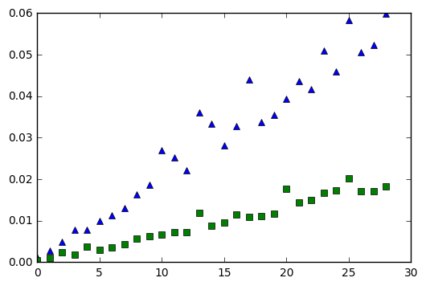

```python
%matplotlib inline
import matplotlib.pyplot as plt
plt.plot(heapsort_times, 'b^')
plt.plot(mergesort_times, 'gs')
plt.show()
```

#### Example: Making Change

Question: how many different ways are there of making up a specified amount of money, given a list of available denominations?

E.g., how many ways of making 10 cents, given 1c, 5c, 10c, 25c coins?

Key observation: the number of ways we can make up some amount $N$ using $k$ different denominations is equal to:

- the number of ways we can make $N$ excluding some denomination $d_i$, **plus**
- the number of ways we can make $(N - d_i)$ using all $k$ denominations

```python
def change(amount, denoms):
    if amount == 0:
        return 1
    elif amount < 0 or not denoms:
        return 0
    else:
        return (change(amount, denoms[1:])
                + change(amount-denoms[0], denoms))
```

```python
change(5, (1, 5, 10, 25))
```

```
2
```

```python
change(100, (1, 5, 10, 25))
```

```
242
```

Followup question: can we list the actual ways of making change?

```python
# approach 1: build a tuple on the way "down" the recursion
def change(amount, denoms, way=()):
    if amount == 0:
        print(way)
        return 1
    elif amount < 0 or not denoms:
        return 0
    else:
        return (change(amount, denoms[1:], way)
                + change(amount-denoms[0], denoms, way + (denoms[0],)))
```

```python
change(5, (1, 5, 10, 25))
```

```
(5,)
(1, 1, 1, 1, 1)
```

```
2
```

```python
change(10, (1, 5, 10, 25))
```

```
(10,)
(5, 5)
(1, 1, 1, 1, 1, 5)
(1, 1, 1, 1, 1, 1, 1, 1, 1, 1)
```

```
4
```

```python
# approach 2: build a list of tuples on the way back "up" the recursion
def change(amount, denoms):
    if amount == 0:
        return [()]
    elif amount < 0 or not denoms:
        return []
    else:
        ways = []
        ways.extend(change(amount, denoms[1:]))
        ways.extend([w + (denoms[0],) for w in change(amount-denoms[0], denoms)])
        return ways
```

```python
change(10, (1, 5, 10, 25))
```

```
[(10,), (5, 5), (5, 1, 1, 1, 1, 1), (1, 1, 1, 1, 1, 1, 1, 1, 1, 1)]
```

## 3. The Call Stack

### Simulating recursive `factorial`

```python
class Stack(list):
    push = list.append
    pop  = lambda self: list.pop(self, -1)
    peek = lambda self: self[-1]
    empty = lambda self: len(self) == 0
```

```python
call_stack = Stack()

def call(arg):
    call_stack.push('<frame begin>')
    call_stack.push(('arg', arg))

def get_arg():
    return call_stack.peek()[-1]

def save_local(name, val):
    call_stack.push(('local', name, val))

def restore_local():
    return call_stack.pop()[2]

def return_with(val):
    while call_stack.pop() != '<frame begin>':
        pass
    call_stack.push(('ret', val))

def last_return_val():
    return call_stack.pop()[-1]
```

```python
call(10) # initial call
while True: # recursive calls
    n = get_arg()
    if n == 1:
        return_with(1)
        break
    else:
        save_local('n', n)
        call(n-1)
```

```python
call_stack
```

```
['<frame begin>',
 ('arg', 10),
 ('local', 'n', 10),
 '<frame begin>',
 ('arg', 9),
 ('local', 'n', 9),
 '<frame begin>',
 ('arg', 8),
 ('local', 'n', 8),
 '<frame begin>',
 ('arg', 7),
 ('local', 'n', 7),
 '<frame begin>',
 ('arg', 6),
 ('local', 'n', 6),
 '<frame begin>',
 ('arg', 5),
 ('local', 'n', 5),
 '<frame begin>',
 ('arg', 4),
 ('local', 'n', 4),
 '<frame begin>',
 ('arg', 3),
 ('local', 'n', 3),
 '<frame begin>',
 ('arg', 2),
 ('local', 'n', 2),
 ('ret', 1)]
```

```python
ret = last_return_val()
n = restore_local()
return_with(n * ret)
call_stack
```

[output not shown]

### Debugging with `pdb` and `%debug`

```python
import sys
sys.setrecursionlimit(100)
```

```python
def rec_factorial(n):
    if n <= 1:   # detect base case
        raise Exception('base case!')
    else:
        return n * rec_factorial(n-1)
```

```python
rec_factorial(10)
```

```
---------------------------------------------------------------------------
Exception                                 Traceback (most recent call last)
<ipython-input-50-f914dbc0d6f8> in <module>()
----> 1 rec_factorial(10)

<ipython-input-49-0eb6f9e46905> in rec_factorial(n)
      3         raise Exception('base case!')
      4     else:
----> 5         return n * rec_factorial(n-1)

<ipython-input-49-0eb6f9e46905> in rec_factorial(n)
      3         raise Exception('base case!')
      4     else:
----> 5         return n * rec_factorial(n-1)

<ipython-input-49-0eb6f9e46905> in rec_factorial(n)
      3         raise Exception('base case!')
      4     else:
----> 5         return n * rec_factorial(n-1)

<ipython-input-49-0eb6f9e46905> in rec_factorial(n)
      3         raise Exception('base case!')
      4     else:
----> 5         return n * rec_factorial(n-1)

<ipython-input-49-0eb6f9e46905> in rec_factorial(n)
      3         raise Exception('base case!')
      4     else:
----> 5         return n * rec_factorial(n-1)

<ipython-input-49-0eb6f9e46905> in rec_factorial(n)
      3         raise Exception('base case!')
      4     else:
----> 5         return n * rec_factorial(n-1)

<ipython-input-49-0eb6f9e46905> in rec_factorial(n)
      3         raise Exception('base case!')
      4     else:
----> 5         return n * rec_factorial(n-1)

<ipython-input-49-0eb6f9e46905> in rec_factorial(n)
      3         raise Exception('base case!')
      4     else:
----> 5         return n * rec_factorial(n-1)

<ipython-input-49-0eb6f9e46905> in rec_factorial(n)
      3         raise Exception('base case!')
      4     else:
----> 5         return n * rec_factorial(n-1)

<ipython-input-49-0eb6f9e46905> in rec_factorial(n)
      1 def rec_factorial(n):
      2     if n <= 1:   # detect base case
----> 3         raise Exception('base case!')
      4     else:
      5         return n * rec_factorial(n-1)

Exception: base case!
```

```python
%debug
# commands to try:
# help, where, args, p n, up, u 10, down, d 10, l, up 100, u, d (& enter to repeat)
```

```python
def bin_search(x, lst):
    if len(lst) == 0:
        return False
    else:
        print('lo, hi = ', (lst[0], lst[-1]))
        mid = len(lst) // 2
        if x == lst[mid]:
            import pdb ; pdb.set_trace()
            return True
        elif x < lst[mid]:
            return bin_search(x, lst[:mid])
        else:
            return bin_search(x, lst[mid+1:])
```

```python
bin_search(20, list(range(100)))
```

```
lo, hi =  (0, 99)
lo, hi =  (0, 49)
lo, hi =  (0, 24)
lo, hi =  (13, 24)
lo, hi =  (20, 24)
lo, hi =  (20, 21)
lo, hi =  (20, 20)
> <ipython-input-51-0c8fd9d61981>(9)bin_search()
-> return True
(Pdb) p mid
0
(Pdb) q
```

[output not shown]

[output cut: 17 more lines]

[output not shown]